# exploratory_analysis

#### Decisiones con outliers de baja cardinalidad

```python
# Volvemos a leer las columnas de baja cardinalidad
low_cardinality_under50 = [col for col in df_clean.columns if df_clean[col].dtype in ['int64', 'float64'] and df_clean[col].nunique() < 50]
# eliminamos las binarias
low_cardinality_under50.remove('previous_bookings_not_canceled')
# low_cardinality_under50.remove('days_in_waiting_list')
low_cardinality_under50.remove('is_repeated_guest')
```

```python
df_clean[low_cardinality_under50].nunique().sort_values(ascending=False)
```

```
stays_in_week_nights           35
arrival_date_day_of_month      31
booking_changes                21
stays_in_weekend_nights        17
previous_cancellations         15
adults                         14
total_of_special_requests       6
children                        5
babies                          5
required_car_parking_spaces     5
arrival_date_year               3
dtype: int64
```

```python
# Vamos a ver la asimetría de las variables de baja cardinalidad
print('__________asimetría de las variables de baja cardinalidad__________')
print(df_clean[low_cardinality_under50].skew().sort_values(ascending=False))
# Vemos la curtosis de las variables de baja cardinalidad
print('__________curtosis de las variables de baja cardinalidad__________')
print(df_clean[low_cardinality_under50].kurtosis().sort_values(ascending=False))
```

```
__________asimetría de las variables de baja cardinalidad__________
babies                         24.646545
previous_cancellations         24.458049
adults                         18.317805
booking_changes                 6.000270
required_car_parking_spaces     4.163233
children                        4.112670
stays_in_week_nights            2.862249
stays_in_weekend_nights         1.380046
total_of_special_requests       1.349189
arrival_date_day_of_month      -0.002000
arrival_date_year              -0.232583
dtype: float64
__________curtosis de las variables de baja cardinalidad__________
babies                         1633.948235
adults                         1352.115116
previous_cancellations          674.073693
booking_changes                  79.393605
required_car_parking_spaces      29.998056
stays_in_week_nights             24.284555
children                         18.674464
stays_in_weekend_nights           7.174066
total_of_special_requests         1.492565
arrival_date_year                -0.994564
arrival_date_day_of_month        -1.187168
dtype: float64
```

Las variables adults, previous cancellations, babies, booking changes tienen una asimetría y una kurtosis muy significativa, por lo que vamos a aplicar un tratamiento de outliers específico

```python
# seleccionamios estas variables
low_cardinality_high_skew = df_clean[low_cardinality_under50].skew().sort_values(ascending=False)[0:4].index.tolist()

df_clean[low_cardinality_high_skew].describe(percentiles=[.25, .5, .75, .9, .95, .99]).T.sort_values(by='50%', ascending=False).style.background_gradient(cmap='coolwarm')
```

|  | count | mean | std | min | 25% | 50% | 75% | 90% | 95% | 99% | max |
| --- | --- | --- | --- | --- | --- | --- | --- | --- | --- | --- | --- |
| adults | 119390.000000 | 1.856403 | 0.579261 | 0.000000 | 2.000000 | 2.000000 | 2.000000 | 2.000000 | 3.000000 | 3.000000 | 55.000000 |
| babies | 119390.000000 | 0.007949 | 0.097436 | 0.000000 | 0.000000 | 0.000000 | 0.000000 | 0.000000 | 0.000000 | 0.000000 | 10.000000 |
| previous_cancellations | 119390.000000 | 0.087118 | 0.844336 | 0.000000 | 0.000000 | 0.000000 | 0.000000 | 0.000000 | 1.000000 | 1.000000 | 26.000000 |
| booking_changes | 119390.000000 | 0.221124 | 0.652306 | 0.000000 | 0.000000 | 0.000000 | 0.000000 | 1.000000 | 1.000000 | 3.000000 | 21.000000 |

```python
"""atendiendo a estos datos, vamos a eliminar los valores que superen el p99, ya que no tienen sentido en el contexto del negocio. No tiene sentido imputar por la mediana
porque si atendemos al concepto del negocio, se trata de clientes muy particulares a nivel adultos (grupos), de niños (familias extremadamente numerosas)"""
df_hypo_q99_plus = df_clean[low_cardinality_high_skew]

# Iterar sobre cada columna en low_cardinality_hgh_skew y eliminar los valores que superen el percentil 99
for col in low_cardinality_high_skew:
    p99 = df_hypo_q99_plus[col].quantile(0.99) + 3
    df_hypo_q99_plus = df_hypo_q99_plus[df_hypo_q99_plus[col] <= p99]

# Mostrar los primeros 10 registros del DataFrame filtrado
print(f'elementos eliminados: {df_clean.shape[0] - df_hypo_q99_plus.shape[0]}')

df_hypo_q99_plus.describe(percentiles=[.25, .5, .75, .9, .95, .99]).T.sort_values(by='50%', ascending=False).style.background_gradient(cmap='coolwarm')
```

```
elementos eliminados: 322
```

|  | count | mean | std | min | 25% | 50% | 75% | 90% | 95% | 99% | max |
| --- | --- | --- | --- | --- | --- | --- | --- | --- | --- | --- | --- |
| adults | 119068.000000 | 1.853672 | 0.488932 | 0.000000 | 2.000000 | 2.000000 | 2.000000 | 2.000000 | 3.000000 | 3.000000 | 6.000000 |
| babies | 119068.000000 | 0.007811 | 0.089452 | 0.000000 | 0.000000 | 0.000000 | 0.000000 | 0.000000 | 0.000000 | 0.000000 | 2.000000 |
| previous_cancellations | 119068.000000 | 0.055447 | 0.246417 | 0.000000 | 0.000000 | 0.000000 | 0.000000 | 0.000000 | 1.000000 | 1.000000 | 4.000000 |
| booking_changes | 119068.000000 | 0.214516 | 0.593814 | 0.000000 | 0.000000 | 0.000000 | 0.000000 | 1.000000 | 1.000000 | 3.000000 | 6.000000 |

Como podemos ver, después de hacer una prueba iterativa, hemos considerado que eliminar los valores por encima del p99 + 3 es lo más adecuado. Si consideramos que en algún momento estos outliers pueden afectar al modelo, podemos aplicar un tratamiento diferente, como la transformación logarítmica o la transformación Box-Cox. Sin embargo, en este caso, vamos a optar por dejarlo de esta forma

**Importante!!!!** Cabe destacar que el outliers inferiores no son muy significativos, por lo que no los vamos a eliminar. En algunos casos, como el valor 0 de adultos, puede despertar alguna duda, porque no es común una reserva sin adultos. Para eliminar esos datos, que reportan ~400 casos, deberíamos conocer bien el contexto del negocio y entender porqué puede ser 0 ese valor. Si se trata de un error, podríamos eliminarlo, pero si se trata de una reserva diferente (ej, gubernamental) no sería correcto eliminarlo. En este caso, vamos a dejarlo como está.

```python
# Eliminamos el indice de los registros eliminados
df_clean = df_clean[df_clean.index.isin(df_hypo_q99_plus.index)]


# Aceptamos el experimento, modificamos los valores
for col in low_cardinality_high_skew:
    df_clean[col] = df_hypo_q99_plus[col]
```

# Análisis Multivariante

```python
numeric_cols
```

```
['lead_time',
 'arrival_date_year',
 'arrival_date_week_number',
 'arrival_date_day_of_month',
 'stays_in_weekend_nights',
 'stays_in_week_nights',
 'adults',
 'children',
 'babies',
 'is_repeated_guest',
 'previous_cancellations',
 'booking_changes',
 'adr',
 'required_car_parking_spaces',
 'total_of_special_requests']
```

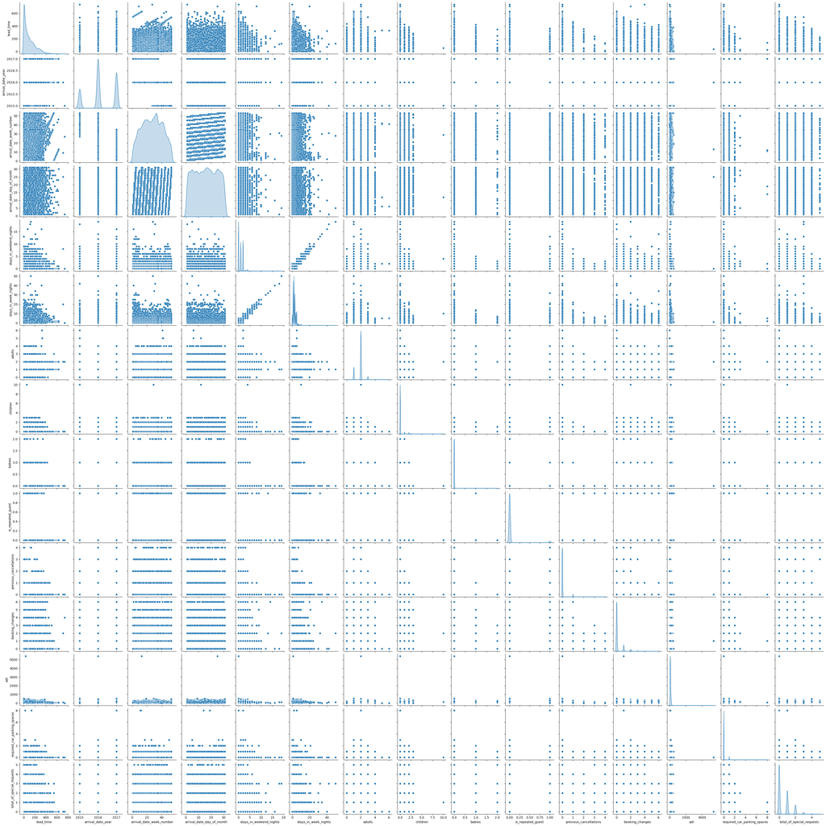

```python
 # Hacemos Pairplot para las variables numéricas

sns.pairplot(df_clean[numeric_cols], diag_kind='kde')
plt.show()
```

```python
numeric_cols_with_target = numeric_cols.copy()
numeric_cols_with_target.append('is_canceled')

corr = df_clean[numeric_cols_with_target].corr()
corr_target = corr['is_canceled'].sort_values(ascending=False)
corr_target
```

```
is_canceled                    1.000000
lead_time                      0.291532
previous_cancellations         0.242598
adults                         0.062262
adr                            0.049103
stays_in_week_nights           0.025591
arrival_date_year              0.019676
arrival_date_week_number       0.006856
children                       0.005532
stays_in_weekend_nights       -0.001400
arrival_date_day_of_month     -0.005154
babies                        -0.034026
is_repeated_guest             -0.084419
booking_changes               -0.152392
required_car_parking_spaces   -0.195398
total_of_special_requests     -0.233587
Name: is_canceled, dtype: float64
```

```python
# Análizamos la relación entre variables categóricas mediante chi-cuadrado
def chi_square_test(df, col1, col2):
    contingency_table = pd.crosstab(df[col1], df[col2])
    chi2, p, _, _ = chi2_contingency(contingency_table)
    return chi2, p
def analyze_categorical_relationships(df, categorical_cols):
    results = []
    for i in range(len(categorical_cols)):
        for j in range(i + 1, len(categorical_cols)):
            col1 = categorical_cols[i]
            col2 = categorical_cols[j]
            chi2, p = chi_square_test(df, col1, col2)
            results.append((col1, col2, chi2, p))
    return results
categorical_relationships = analyze_categorical_relationships(df_clean, str_cols)
results_df = pd.DataFrame(categorical_relationships, columns=['col1', 'col2', 'chi2', 'p-value'])
results_df['significant'] = results_df['p-value'] < 0.05

results_df['p-value'] = results_df['p-value'].apply(lambda x: '{:.2e}'.format(x))
results_df['chi2'] = results_df['chi2'].apply(lambda x: '{:.2f}'.format(x))
results_df.sort_values(by='chi2', ascending=False, inplace=True)
results_df
```

|  | col1 | col2 | chi2 | p-value | significant |
| --- | --- | --- | --- | --- | --- |
| 25 | meal | country | 9650.86 | 0.00e+00 | True |
| 12 | hotel | agent | 92209.03 | 0.00e+00 | True |
| 51 | market_segment | reservation_status | 9053.31 | 0.00e+00 | True |
| 70 | assigned_room_type | deposit_type | 8728.77 | 0.00e+00 | True |
| 53 | market_segment | is_canceled | 8416.13 | 0.00e+00 | True |
| 38 | country | reserved_room_type | 8148.01 | 0.00e+00 | True |
| 24 | arrival_date_month | agent | 76277.28 | 0.00e+00 | True |
| 84 | customer_type | agent | 73592.34 | 0.00e+00 | True |
| 52 | market_segment | reservation_status_date | 72349.35 | 0.00e+00 | True |
| 39 | country | assigned_room_type | 7112.01 | 0.00e+00 | True |
| 22 | arrival_date_month | reservation_status_date | 694319.36 | 0.00e+00 | True |
| 31 | meal | customer_type | 6924.33 | 0.00e+00 | True |
| 78 | deposit_type | reservation_status_date | 66026.84 | 0.00e+00 | True |
| 66 | reserved_room_type | reservation_status | 660.99 | 1.06e-128 | True |
| 63 | reserved_room_type | assigned_room_type | 646315.32 | 0.00e+00 | True |
| 15 | arrival_date_month | market_segment | 6433.33 | 0.00e+00 | True |
| 29 | meal | assigned_room_type | 6383.93 | 0.00e+00 | True |
| 68 | reserved_room_type | is_canceled | 635.61 | 4.74e-131 | True |
| 0 | hotel | arrival_date_month | 628.20 | 1.30e-127 | True |
| 23 | arrival_date_month | is_canceled | 572.62 | 1.00e-115 | True |
| 37 | country | distribution_channel | 5583.33 | 0.00e+00 | True |
| 64 | reserved_room_type | deposit_type | 5468.97 | 0.00e+00 | True |
| 41 | country | customer_type | 5426.65 | 0.00e+00 | True |
| 80 | deposit_type | agent | 54035.54 | 0.00e+00 | True |
| 28 | meal | reserved_room_type | 5124.31 | 0.00e+00 | True |
| 82 | customer_type | reservation_status_date | 50688.59 | 0.00e+00 | True |
| 33 | meal | reservation_status_date | 50581.52 | 0.00e+00 | True |
| 72 | assigned_room_type | reservation_status | 5010.25 | 0.00e+00 | True |
| 74 | assigned_room_type | is_canceled | 4861.58 | 0.00e+00 | True |
| 55 | distribution_channel | reserved_room_type | 4804.28 | 0.00e+00 | True |

[output cut: 61 more lines]